# Clase 5 - El paquete GGPlot2

Ggplot 2 es el paquete más avanzado en R. Utiliza la gramática de los gráficos y permite crear visualizaciones tan personalizadas como cuanto uno quiera. Pertenece al paquete tidiverse.

- ReadR - Importa datos en diversos formatos, siendo el mejor ejemplo `read_csv()`
- Tibble - Crea una estructura de datos similar a la data frame que facilita la manipulacion de datos
- Permite filtrar resumir y manipular datos
- tidyr - Organiza datos en forma tidy

Lo primero que debemos hacer es cargar la library, ya sea mediante invocando todo el `tidyverse` (recomendado) o unicamente `ggplot2`

A continuacion vamos a realizar los graficos

## Gramatica de graficos

La gramatica de graficos es el andamiaje que permite cre ar y personalizar los graficos desde cero, proveyendo una fuente de datos. Los elementos más básicos de esta gramática son:

- La fuente de datos que uno va a utilizar (`data`)
- La forma que va a tomar los datos en la visualizacion, o su geometria (`geom`), por ejemplo puntos, líneas, barras.
- Las propiedades esteticas (aesthetics) de las geometrias `aes` por ejemplo qué datos van en los ejes, representar un color para una variable, o el diametro de un punto para otra. O sea que no estamos diciendo que un punto sea rojo porque se lo decimos nosotros. Le estamos diciendo a ggplot que nos “mapee” una determinada variable a la propiedad color de un gráfico.

## Iniciando en ggplot2

La primera visualizacion que vamos a realizar esta basada en la base de datos `iris` que contiene las medidas de tres especies del genero *Iris*: *setosa, virginica y versicolor*. Esto es tipo [Wikipedia](http://wikipedia.org)

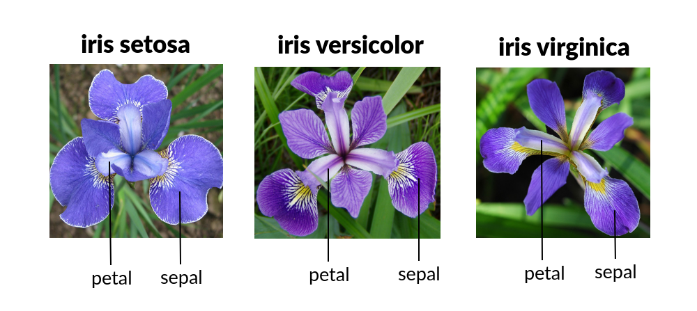

**Flores de *Iris***

Una vez cargada la library, podemos ejecutar por primera vez el comando `ggplot` OJO SIN EL 2 AL FINAL! (si, es confuso para la mierda, pero bueno es lo que hay). Al ejecutarlo sin parametros, observamos que nos muestra un grafico totalmente en blanco.

```r
ggplot()
```

Si ahora especificamos la fuente de los datos en el parametro `data =`:

```r
ggplot(data = iris)
```

Nuevamente no tenemos ninguna salida significativa. Creemos un grafico de puntos con los datos que tenemos, simplemente agregando mas informacion (naturalmetne, utilizando el signo “+”) sobre la geometria que vamos a trabajar. En ggplot, todas las geometrias funcionan con el prefijo `geom_` asi que resulta fácil encontrarlas cuando las necesitemos. Para orientar a la funcion qué es lo que vamos a mapear en sus coordenadas, utilizaremos el parámetro `mapping =`, seguido de la funcion que define las propiedades esteticas del grafico `aes()`.

[figure not shown]

Ahora continuamos con otra de las bases del paquete “nativo” (que ya viene preinstalado en R) `trees`. Veamos que contiene acudiendo a la ayuda.

```r
help("trees")
```

Sabremos entonces que la database tiene 3 variables: diametro, altura y volumen del cerecero negro.

Ahora vamos a continuar haciendo un scatterplot, utilizando la geometria point, siguiendo los mismos pasos que el caso anterior.

```r
ggplot(data = trees) +
  geom_point(mapping = aes(x = Girth, y = Volume))
```

[output not shown]

[output not shown]

[figure not shown]

# Agregado durante la clase

Lo que hacemos a continuación es crear una linea de tendencia basada en un modelo lineal `lm` que hace la estadística por nosotros. Hasta donde sé, el lugar donde se definen las `aesthetics` no altera si lo hace en la funcion `ggplot()` o dentro de `geom_point()`. En los códigos que veo por ahi, usualmente están de esta manera.

```r
ggplot(data = trees, aes(x = Girth, y = Volume)) +
  geom_point() +
  geom_smooth(method = "lm")
```

[output not shown]